# A3: Incarceration

###### 2/25/2022

### Introduction

The incarceration rate varies from year to year in the United States. This may be due to demographic changes, policy changes, and the impact of social events each year. Many people will wonder which year had the largest number of incarcerated population. What happened in that year? And which state had the highest number of people incarcerated? This report examines data collected by the Vera Institute to provide a basic understanding of the complex issue in our society.

Variables that will be analyzed:

- Time: What is the trend in incarceration? Which year has the highest total jail population? Time is the variable that can show the trend will tell people incarceration will be going in the future.
- Total jail population VS black jail population (2008): Is the black jail population in the United States related to the total jail population in each county? What does the incarceration rate for blacks look like? This will tell us the connection.
- Total jail population VS White jail population (2008): Is the white jail population in the United States related to the total jail population in each county? What does the incarceration rate for white look like? This will tell us the connection.
- States: I chose to focus on five states, including California, Washington, D.C., Utah, and New York. Because as an international student, these are the only five states I have visited in the U.S., I wanted to study the incarceration rates in the states I have visited.

### The Dataset

The data was collected by the U.S. Department of Justice Bureau of Justice Statistics (BJS). The BJS datasets included NCRP, DCRP, ASJ, and COJ. These 4 programs provide detailed individual-level data on admissions and releases from state prison authorities, including county of commitment. The data is collected because the institution wants to provide detail on the sources and variables in the Incarceration Trends dataset in order to make people easily to visualize the data. There are 153811 rows and 121 columns in the dataset. When we work with the data, we need to consider to protect individual’s privacy. We can focus on big data to visualize the dataset, instead of just focus on one row of the data. There’s may be some limitations with the data, including the inconsistencies and/or errors existing in the data. For example, data will be collected from different sources or in different institution. These data can vary in quality and format, such as in surveys, e-mails, or data-entry forms. Such data requires major preprocessing before it’s analysis-ready. Also, If the program using data from surveys, we need to consider that people may not always provide accurate information. People may not be dishonest so much as self-conscious, but the data is still skewed.

### Trends Over Time Chart

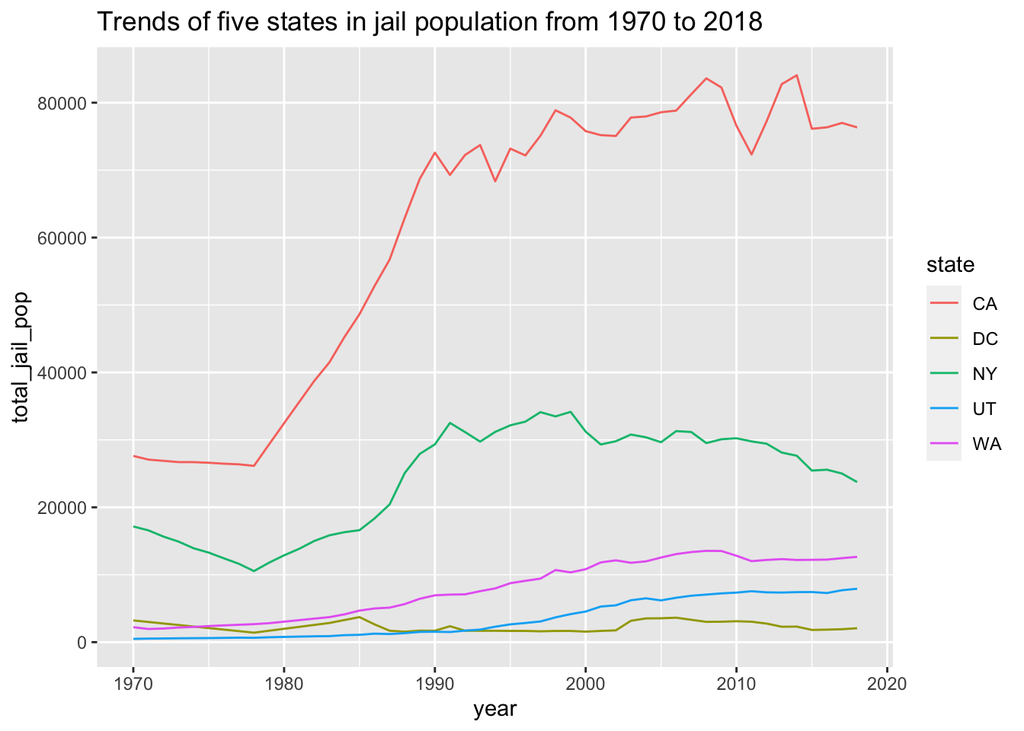

### Variable Comparison Chart

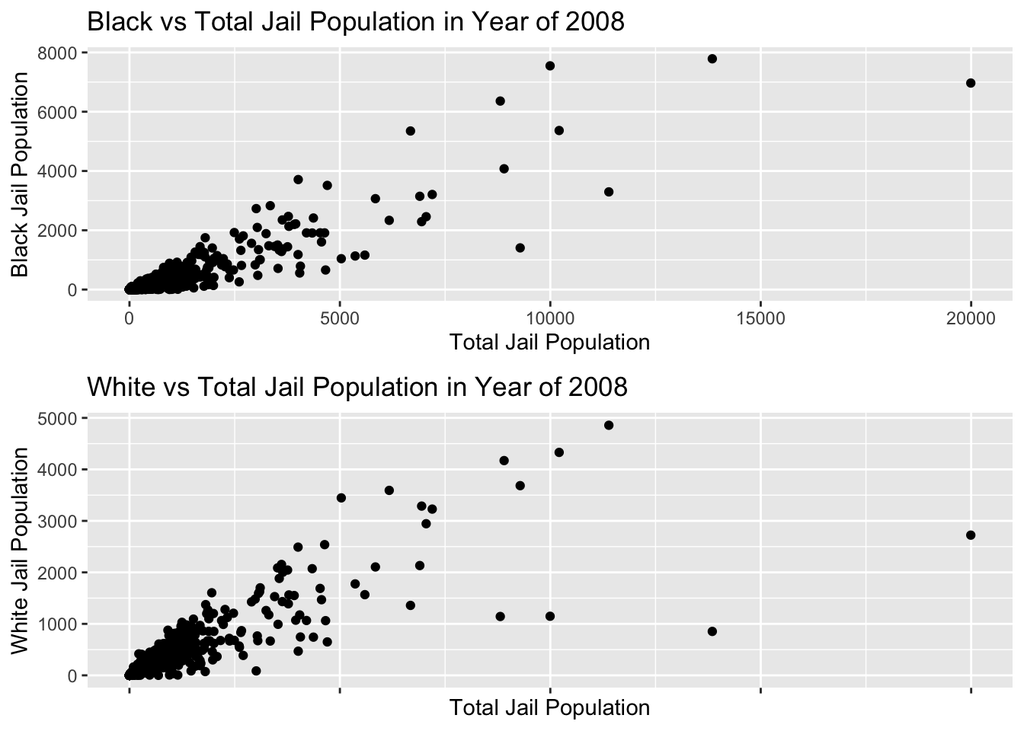

### Map

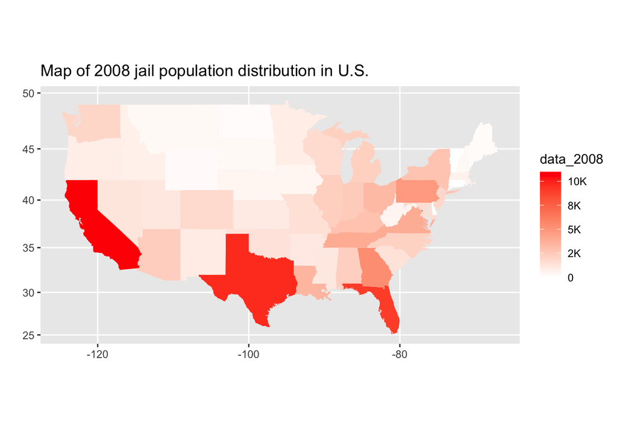

This is a map that reflects the total jail population distribution in U.S. in 2008. In the graph, the color red means the jail population density is high and the color white means the jail population density is low. We can see that California has the highest population in jail, which also consistent with the calculation result. We can also see that the number of people in jail is higher in the eastern part of the country than in the central part of the United States because of the higher population density in the east.